# amahmoo6_assignment1

```python
import os
import pandas as pd
```

```python
os.getcwd()
```

```
'C:\\Users\\A_mah\\PycharmProjects\\amahmoo6_assignment_1_cap5615'
```

```python
%matplotlib inline
import matplotlib.pyplot as plt
import pandas as pd
import numpy as np
df = pd.read_csv("housing.header.txt")
print(df.shape)
```

```
(506, 14)
```

```python
df.head()
```

|  | Crim | Zn | Indus | Chas | Nox | Rm | Age | Dis | Rad | Tax | Ptratio | B | Lstat | Medv |
| --- | --- | --- | --- | --- | --- | --- | --- | --- | --- | --- | --- | --- | --- | --- |
| 0 | 0.00632 | 18.0 | 2.31 | 0 | 0.538 | 6.575 | 65.2 | 4.0900 | 1 | 296 | 15.3 | 396.90 | 4.98 | 24.0 |
| 1 | 0.02731 | 0.0 | 7.07 | 0 | 0.469 | 6.421 | 78.9 | 4.9671 | 2 | 242 | 17.8 | 396.90 | 9.14 | 21.6 |
| 2 | 0.02729 | 0.0 | 7.07 | 0 | 0.469 | 7.185 | 61.1 | 4.9671 | 2 | 242 | 17.8 | 392.83 | 4.03 | 34.7 |
| 3 | 0.03237 | 0.0 | 2.18 | 0 | 0.458 | 6.998 | 45.8 | 6.0622 | 3 | 222 | 18.7 | 394.63 | 2.94 | 33.4 |
| 4 | 0.06905 | 0.0 | 2.18 | 0 | 0.458 | 7.147 | 54.2 | 6.0622 | 3 | 222 | 18.7 | 396.90 | 5.33 | 36.2 |

#### There are 14 attributes in each case of the dataset. They are:

#### CRIM - per capita crime rate by town

#### ZN - proportion of residential land zoned for lots over 25,000 sq.ft.

#### INDUS - proportion of non-retail business acres per town.

#### CHAS - Charles River dummy variable (1 if tract bounds river; 0 otherwise)

#### NOX - nitric oxides concentration (parts per 10 million)

#### RM - average number of rooms per dwelling

#### AGE - proportion of owner-occupied units built prior to 1940

#### DIS - weighted distances to five Boston employment centres

#### RAD - index of accessibility to radial highways

#### TAX - full-value property-tax rate per 10000 dollars

#### PTRATIO - pupil-teacher ratio by town

#### B - 1000(Bk - 0.63)^2 where Bk is the proportion of blacks by town

#### LSTAT - % lower status of the population

#### MEDV - Median value of owner-occupied homes in $1000's

```python
df.describe()
```

|  | Crim | Zn | Indus | Chas | Nox | Rm | Age | Dis | Rad | Tax | Ptratio | B | Lstat | Medv |
| --- | --- | --- | --- | --- | --- | --- | --- | --- | --- | --- | --- | --- | --- | --- |
| count | 506.000000 | 506.000000 | 506.000000 | 506.000000 | 506.000000 | 506.000000 | 506.000000 | 506.000000 | 506.000000 | 506.000000 | 506.000000 | 506.000000 | 506.000000 | 506.000000 |
| mean | 3.613524 | 11.363636 | 11.136779 | 0.069170 | 0.554695 | 6.284634 | 68.574901 | 3.795043 | 9.549407 | 408.237154 | 18.455534 | 356.674032 | 12.653063 | 22.532806 |
| std | 8.601545 | 23.322453 | 6.860353 | 0.253994 | 0.115878 | 0.702617 | 28.148861 | 2.105710 | 8.707259 | 168.537116 | 2.164946 | 91.294864 | 7.141062 | 9.197104 |
| min | 0.006320 | 0.000000 | 0.460000 | 0.000000 | 0.385000 | 3.561000 | 2.900000 | 1.129600 | 1.000000 | 187.000000 | 12.600000 | 0.320000 | 1.730000 | 5.000000 |
| 25% | 0.082045 | 0.000000 | 5.190000 | 0.000000 | 0.449000 | 5.885500 | 45.025000 | 2.100175 | 4.000000 | 279.000000 | 17.400000 | 375.377500 | 6.950000 | 17.025000 |
| 50% | 0.256510 | 0.000000 | 9.690000 | 0.000000 | 0.538000 | 6.208500 | 77.500000 | 3.207450 | 5.000000 | 330.000000 | 19.050000 | 391.440000 | 11.360000 | 21.200000 |
| 75% | 3.677083 | 12.500000 | 18.100000 | 0.000000 | 0.624000 | 6.623500 | 94.075000 | 5.188425 | 24.000000 | 666.000000 | 20.200000 | 396.225000 | 16.955000 | 25.000000 |
| max | 88.976200 | 100.000000 | 27.740000 | 1.000000 | 0.871000 | 8.780000 | 100.000000 | 12.126500 | 24.000000 | 711.000000 | 22.000000 | 396.900000 | 37.970000 | 50.000000 |

#### Report all samples with respect to the Crim index on a plot (the x-axis show the index of the sample, and the y-axis shows the crim index of the sample).

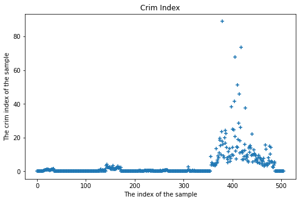

```python
def CrimIndexOnPlotReq():
    dataframecrim = df['Crim']
    x=np.arange(dataframecrim.shape[0])
    plt.figure()
    plt.figure(figsize=(8,5))
    plt.scatter(x, dataframecrim, marker='+')
    plt.title('Crim Index')
    plt.xlabel('The index of the sample')
    plt.ylabel('The crim index of the sample')
    plt.show()
CrimIndexOnPlotReq()
```

#### Show both histogram of the Crim index and the density of the Crim index on a 1x2 frame.

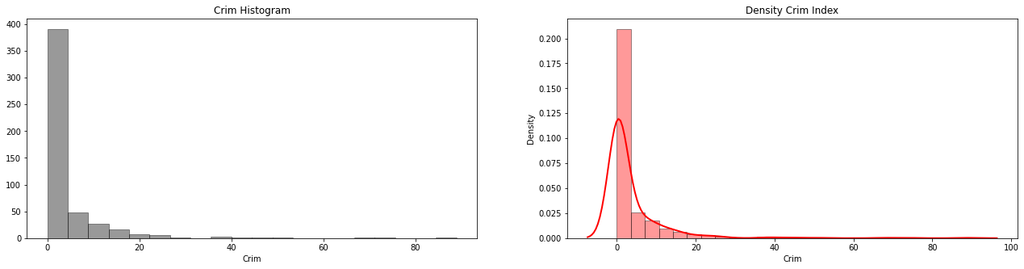

```python
import seaborn as sns
def histogramCrimIndexAndDensity():
    plt.figure(figsize=(22,5))
    plt.subplot(1,2,1)
    sns.distplot(df['Crim'], hist=True, kde=False, bins=20, color = 'black',hist_kws={'edgecolor':'black'})
    plt.title('Crim Histogram')
    plt.subplot(1,2,2)
    sns.distplot(df['Crim'], hist=True, kde=True, bins=25, color = 'red',hist_kws={'edgecolor':'black'},kde_kws={'linewidth':2})
    plt.title('Density Crim Index')
    plt.show()
histogramCrimIndexAndDensity()
```

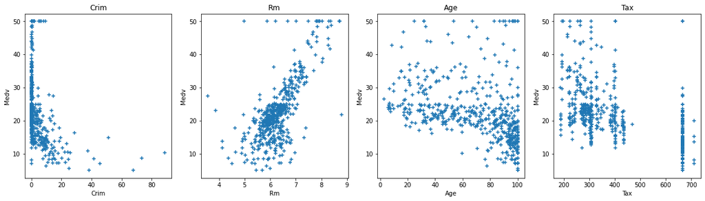

```python
def scatterplotsmedvcoorelation():
    plt.figure(figsize=(20, 5))
    selectedAttributes = ['Crim', 'Rm','Age','Tax']
    medv = df['Medv']
    for i, col in enumerate(selectedAttributes):
        plt.subplot(1, len(selectedAttributes) , i+1)
        x = df[col]
        y = medv
        plt.scatter(x, y, marker='+')
        plt.title(col)
        plt.xlabel(col)
        plt.ylabel('Medv')
scatterplotsmedvcoorelation()
```

#### Create a subset which only includes properties with Crim less than 1 (inclusive), and Rm greater than 6 (inclusive).

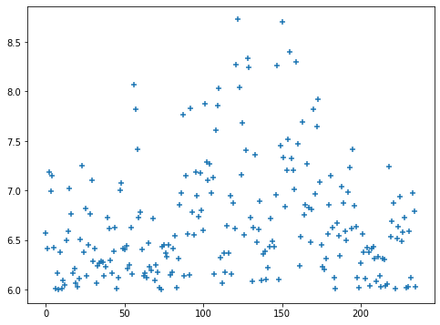

```python
def subset():
    #Create a subset which only includes properties with Crim less than 1 (inclusive), and Rm
    #greater than 6 (inclusive).
    df.filter = df[(df['Crim']<=1) & (df['Rm']>=6)]
    arrangedfiltershape=np.arange(df.filter.shape[0])
    plt.figure(figsize=(8, 6))
    plt.scatter(arrangedfiltershape, df.filter['Rm'], marker='+')
subset()
```

#### Show a scatter plot between Rm and Medv (x-axis shows Rm and y-axis denote Medv), please color all properties with 7 or larger Rm values as “red”, and rest properties as “black”.

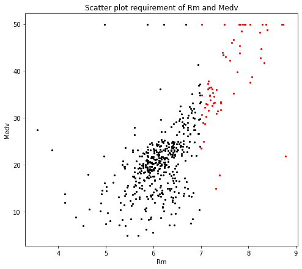

```python
import numpy as np
import matplotlib.pyplot as plt
def scatterrmandmedv():
    rm= df['Rm']
    medv = df['Medv']
    columns=[]
    for i in range(0,len(rm)):
        columns.append('black') if rm[i]<=7 else columns.append('red')
    plt.figure(figsize=(8, 7))
    for i in range(len(rm)):
        plt.scatter(rm[i],medv[i],c=columns[i],s=10, linewidth=0)
        plt.xlabel('Rm')
        plt.ylabel('Medv')
        plt.title('Scatter plot requirement of Rm and Medv')
scatterrmandmedv()
```

#### Report the pairwise correlation between every two variables (either as a matrix or as a level plot)

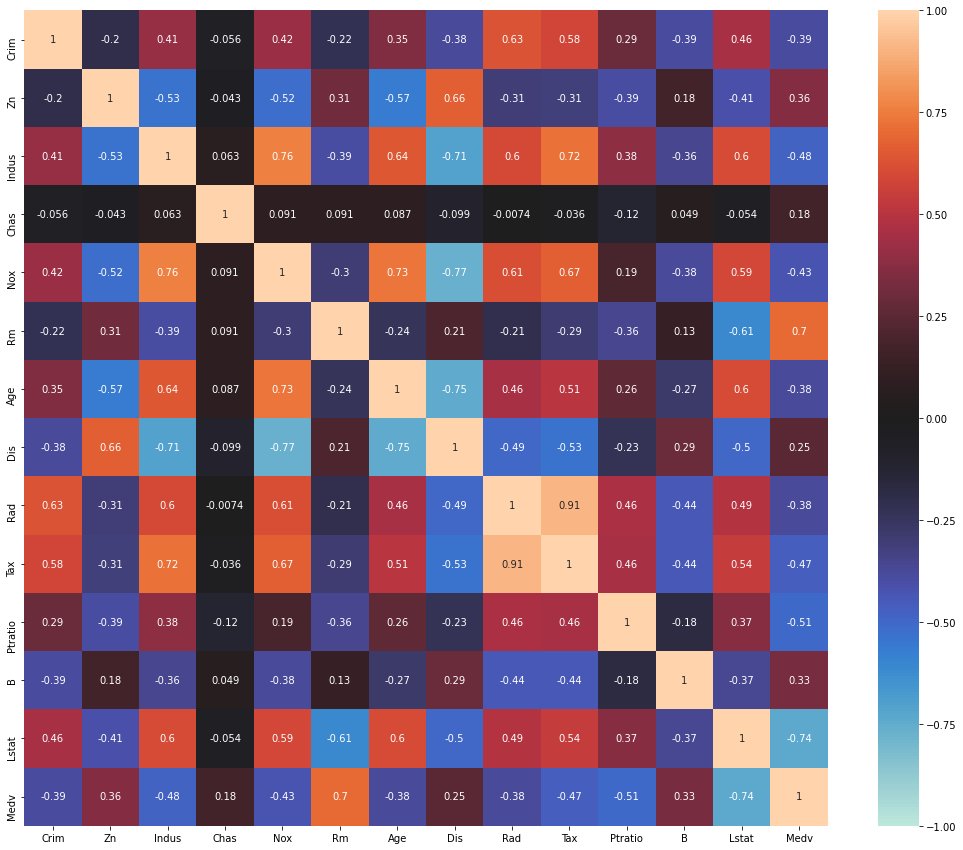

```python
def pairwisecorrelation():
    f, ax = plt.subplots(figsize=(18, 15))
    sns.heatmap(df.corr(), annot = True, vmin=-1, vmax=1, center= 0)
pairwisecorrelation()
```

#### Please explain which variable is mostly positively correlated to Medv (medium house value), and which variable is mostly negatively correlated to Medv.

You can see on the last column for Medv above the most postive in orang was Rm( average number of rooms per dwelling) and for the most negative in blue was Lstat(% lower status of the population)

#### Draw scatterplots to show relationship between each attribute and Medv, respectively.

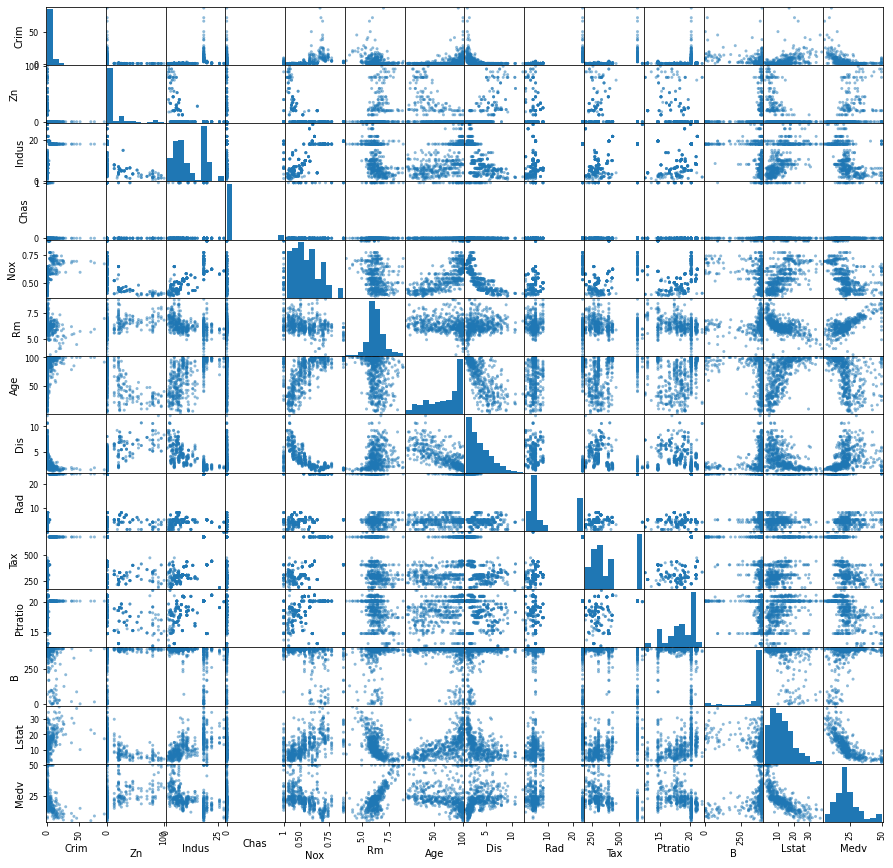

```python
from pandas.plotting import scatter_matrix
def draweachattributeandmedv():
    scatter_matrix(df, figsize=(15, 15))
    plt.show()
draweachattributeandmedv()
```

#### Explain how to use scatterplots to find attributes which are positively correlated, negatively correlated, or independent of Medv, respectively

Coorelation exists within the scatter plot between the y and x axis.To go deeper When looking at the atributes as y increases and x increases its safe to say it is forming a positive coorelation. When y axis starts decling and x declines this forms a negative coorelation. When the value of y start change in random spurts that is self contained from x axis then it has a zero coorelation. These are some attributes that you need to keep in my while making a decision.

Question 9 [2 pts]: Please download movie100.csv dataset from Canvas, and use a programming language (Python, R, etc.) to implement tasks below. The movie100.csv includes 100 move reviews (from IMDB) and the sentiment (positive vs. negative) of the reviewer (there are 50 positive reviews and 50 negative reviews). Each review (each row) contains two part. The first column is the reviews (text), and the second column is the sentiment (positive or negative).

#### Read the movie100.csv, and check average length (in terms of number of words) of the positive and negative reviews, respectively

```python
#read the review100
reviewdf = pd.read_csv("review100.csv")
postiveSentimentReviews = reviewdf[reviewdf['sentiment'].str.contains('positive')]
posword = postiveSentimentReviews['movie review'].str.split().str.len()

negativeSentimentReviews = reviewdf[reviewdf['sentiment'].str.contains('negative')]
negword = negativeSentimentReviews['movie review'].str.split().str.len()
print("average postive review word count:" + str(posword.mean()))
print("average negative review word count:" + str(negword.mean()))
print("positive word count list below")
print(posword)
print("negative list below for word count")
print(negword)
```

```
average postive review word count:271.58
average negative review word count:201.86
positive word count list below
0     307
1     162
2     166
4     230
5     119
6     150
9      33
14     50
16    146
18    129
20    308
22     65
```

[output cut: 91 more lines]

#### Check the frequency of the words with respect to positive and negative reviews, respectively. Print the top 20 most frequent words (including words and their frequency), for positive and negative reviews, respectively

```python
from collections import Counter

posWordTupleList = Counter(" ".join(postiveSentimentReviews['movie review']).split()).most_common(20)
print("positive words")
print(posWordTupleList)
negWordTupleList = Counter(" ".join(negativeSentimentReviews['movie review']).split()).most_common(20)
print("negative words")
print(negWordTupleList)
```

```
positive words
[('the', 738), ('and', 381), ('of', 370), ('a', 342), ('to', 303), ('is', 268), ('in', 227), ('/><br', 126), ('that', 125), ('as', 109), ('his', 103), ('with', 102), ('it', 100), ('for', 93), ('this', 86), ('I', 84), ('was', 79), ('he', 72), ('by', 72), ('on', 70)]
negative words
[('the', 521), ('a', 286), ('to', 249), ('and', 245), ('of', 244), ('is', 167), ('in', 143), ('I', 127), ('this', 107), ('was', 106), ('that', 103), ('/><br', 99), ('it', 92), ('for', 70), ('with', 69), ('but', 67), ('movie', 65), ('The', 65), ('have', 58), ('not', 53)]
```

#### Draw a bar plot to show the frequency of the two-20 most frequent words (the x-axis denotes words, and the y-axis denotes their frequency), for positive and negative reviews, respectively

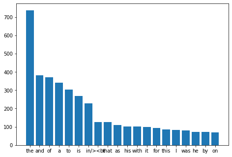

```python
import matplotlib.pyplot as plt

def createPostiveTop20Bar():
    word_list = []
    count_list = []
    for i in posWordTupleList:
        word_list.append(i[0])
        count_list.append(i[1])
    figure = plt.figure()
    graph = figure.add_axes([0,0,1,1])
    graph.bar(word_list,count_list)
    plt.show()
createPostiveTop20Bar()
```

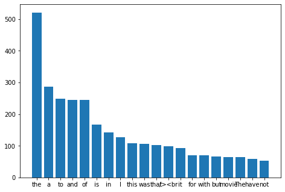

```python
import matplotlib.pyplot as plt

def createNegativeTop20Bar():
    word_list = []
    count_list = []
    for i in negWordTupleList:
        word_list.append(i[0])
        count_list.append(i[1])
    figure = plt.figure()
    graph = figure.add_axes([0,0,1,1])
    graph.bar(word_list,count_list)
    plt.show()
createNegativeTop20Bar()
```